# Topic 6: Topic Analysis

Peter Menzies

5/8/22

```r
knitr::opts_chunk$set(echo = TRUE, message = FALSE, warning = FALSE)

library(here)
library(pdftools)
library(quanteda)
library(tm)
library(topicmodels)
library(ldatuning)
library(tidyverse)
library(tidytext)
library(reshape2)
```

Load the data

```r
comments_df <- readRDS(here("data", "comments_df.RDS"))
```

Now we’ll build and clean the corpus

```r
epa_corp <- corpus(x = comments_df, text_field = "text")
epa_corp.stats <- summary(epa_corp)
head(epa_corp.stats, n = 25)
```

```
##      Text Types Tokens Sentences
## 1   text1  1196   3973       178
## 2   text2   830   2509       111
## 3   text3   279    571        31
## 4   text4  1745   6904       251
## 5   text5   581   1534        49
## 6   text6   469   1187        53
## 7   text7   424    903        38
## 8   text8  3622  22270       655
## 9   text9   373    717        25
## 10 text10   404    971        42
## 11 text11   710   2190        77
## 12 text12   636   1896        82
## 13 text13   146    206         3
## 14 text14  1124   3197        86
```

[output cut: 37 more lines]

```r
toks <- tokens(epa_corp, remove_punct = TRUE, remove_numbers = TRUE)
#I added some project-specific stop words here
add_stops <- c(stopwords("en"),"environmental", "justice", "ej", "epa", "public", "comment")
toks1 <- tokens_select(toks, pattern = add_stops, selection = "remove")
```

And now convert to a document-feature matrix

```r
dfm_comm<- dfm(toks1, tolower = TRUE)
dfm <- dfm_wordstem(dfm_comm)
dfm <- dfm_trim(dfm, min_docfreq = 2) #remove terms only appearing in one doc (min_termfreq = 10)

print(head(dfm))
```

```
## Document-feature matrix of: 6 documents, 2,781 features (82.75% sparse) and 1 docvar.
##        features
## docs    charl lee deputi associ assist administr usepa offic 2201-a
##   text1     1   2      1      1      6         6     1     7      1
##   text2     1   1      1      4      3         1     0     5      0
##   text3     0   0      0      0      1         0     0     2      0
##   text4     0   0      0      0      1         9     0     1      0
##   text5     4   5      1      1      1         1     0     1      1
##   text6     1   1      1      3      1         3     0     4      0
##        features
## docs    pennsylvania
##   text1            1
##   text2            0
##   text3            0
##   text4            0
##   text5            1
##   text6            0
## [ reached max_nfeat ... 2,771 more features ]
```

```r
#remove rows (docs) with all zeros
sel_idx <- slam::row_sums(dfm) > 0
dfm <- dfm[sel_idx, ]
#comments_df <- dfm[sel_idx, ]
```

We somehow have to come up with a value for k,the number of latent topics present in the data. How do we do this? There are multiple methods. Let’s use what we already know about the data to inform a prediction. The EPA has 9 priority areas: Rulemaking, Permitting, Compliance and Enforcement, Science, States and Local Governments, Federal Agencies, Community-based Work, Tribes and Indigenous People, National Measures. Maybe the comments correspond to those areas?

```r
k <- 9

topicModel_k9 <- LDA(dfm, k, method="Gibbs", control=list(iter = 500, verbose = FALSE))
#nTerms(dfm_comm)

tmResult <- posterior(topicModel_k9)
attributes(tmResult)
```

```
## $names
## [1] "terms"  "topics"
```

```r
#nTerms(dfm_comm)
beta <- tmResult$terms   # get beta from results
dim(beta)                # K distributions over nTerms(DTM) terms# lengthOfVocab
```

```
## [1]    9 2781
```

```r
terms(topicModel_k9, 10)
```

```
##       Topic 1     Topic 2   Topic 3     Topic 4      Topic 5     Topic 6
##  [1,] "state"     "state"   "health"    "communiti"  "agenc"     "communiti"
##  [2,] "program"   "permit"  "peopl"     "framework"  "issu"      "plan"
##  [3,] "draft"     "consid"  "citi"      "action"     "address"   "strategi"
##  [4,] "epa"       "comment" "polici"    "develop"    "titl"      "local"
##  [5,] "polici"    "air"     "park"      "agenc"      "vi"        "help"
##  [6,] "feder"     "feder"   "fund"      "effort"     "right"     "can"
##  [7,] "may"       "use"     "right"     "comment"    "plan"      "agenda"
##  [8,] "regul"     "grant"   "climat"    "overburden" "act"       "particip"
##  [9,] "nation"    "organ"   "law"       "tool"       "communiti" "use"
## [10,] "framework" "meet"    "communiti" "improv"     "impact"    "subject"
##       Topic 7     Topic 8     Topic 9
##  [1,] "impact"    "communiti" "prison"
##  [2,] "rule"      "enforc"    "project"
##  [3,] "state"     "monitor"   "popul"
##  [4,] "pollut"    "comment"   "site"
##  [5,] "air"       "includ"    "energi"
##  [6,] "health"    "air"       "industri"
##  [7,] "communiti" "pollut"    "facil"
##  [8,] "popul"     "data"      "peopl"
##  [9,] "also"      "provid"    "sourc"
## [10,] "area"      "health"    "individu"
```

Some of those topics seem related to the cross-cutting and additional topics identified in the EPA’s response to the public comments:

1. Title VI of the Civil Rights Act of 1964

2.[EJSCREEN](https://www.epa.gov/ejscreen/download-ejscreen-data)

3. climate change, climate adaptation and promoting greenhouse gas reductions co-benefits

4. overburdened communities and other stakeholders to meaningfully, effectively, and transparently participate in aspects of EJ 2020, as well as other agency processes

5. utilize multiple Federal Advisory Committees to better obtain outside environmental justice perspectives

6. environmental justice and area-specific training to EPA staff

7. air quality issues in overburdened communities

So we could guess that there might be a 16 topics (9 priority + 7 additional). Or we could calculate some metrics from the data.

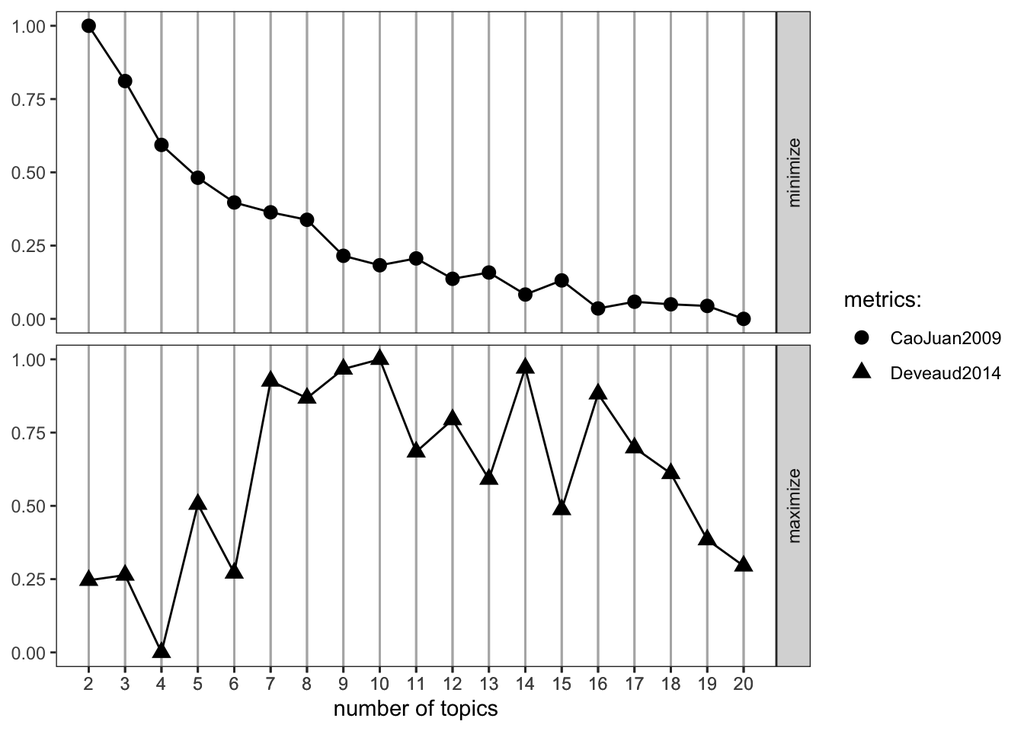

```r
#
result <- FindTopicsNumber(
  dfm,
  topics = seq(from = 2, to = 20, by = 1),
  metrics = c("CaoJuan2009",  "Deveaud2014"),
  method = "Gibbs",
  control = list(seed = 77),
  verbose = FALSE
)

FindTopicsNumber_plot(result)
```

```r
k <- 7

topicModel_k7 <- LDA(dfm, k, method="Gibbs", control=list(iter = 500, verbose = FALSE))

tmResult <- posterior(topicModel_k7)
terms(topicModel_k7, 10)
```

```
##       Topic 1     Topic 2    Topic 3  Topic 4     Topic 5     Topic 6
##  [1,] "communiti" "water"    "right"  "state"     "communiti" "framework"
##  [2,] "plan"      "prison"   "civil"  "pollut"    "enforc"    "draft"
##  [3,] "local"     "popul"    "vi"     "health"    "includ"    "agenc"
##  [4,] "comment"   "project"  "health" "rule"      "comment"   "effort"
##  [5,] "strategi"  "site"     "titl"   "impact"    "monitor"   "state"
##  [6,] "agenda"    "energi"   "peopl"  "communiti" "action"    "tool"
##  [7,] "action"    "facil"    "agenc"  "also"      "data"      "develop"
##  [8,] "mani"      "peopl"    "law"    "popul"     "requir"    "program"
##  [9,] "govern"    "industri" "issu"   "air"       "air"       "action"
## [10,] "particip"  "econom"   "act"    "guidanc"   "pollut"    "communiti"
##       Topic 7
##  [1,] "state"
##  [2,] "permit"
##  [3,] "feder"
##  [4,] "consid"
##  [5,] "requir"
##  [6,] "meet"
##  [7,] "polici"
##  [8,] "air"
##  [9,] "comment"
## [10,] "qualiti"
```

```r
theta <- tmResult$topics
beta <- tmResult$terms
vocab <- (colnames(beta))
```

There are multiple proposed methods for how to measure the best k value. You can [go down the rabbit hole here](https://rpubs.com/siri/ldatuning)

```r
comment_topics <- tidy(topicModel_k7, matrix = "beta")

top_terms <- comment_topics %>%
  group_by(topic) %>%
  top_n(10, beta) %>%
  ungroup() %>%
  arrange(topic, -beta)

top_terms
```

```
## # A tibble: 71 × 3
##    topic term        beta
##    <int> <chr>      <dbl>
##  1     1 communiti 0.0565
##  2     1 plan      0.0222
##  3     1 local     0.0208
##  4     1 comment   0.0150
##  5     1 strategi  0.0140
##  6     1 agenda    0.0134
##  7     1 action    0.0129
##  8     1 mani      0.0106
##  9     1 govern    0.0106
## 10     1 particip  0.0103
## # … with 61 more rows
```

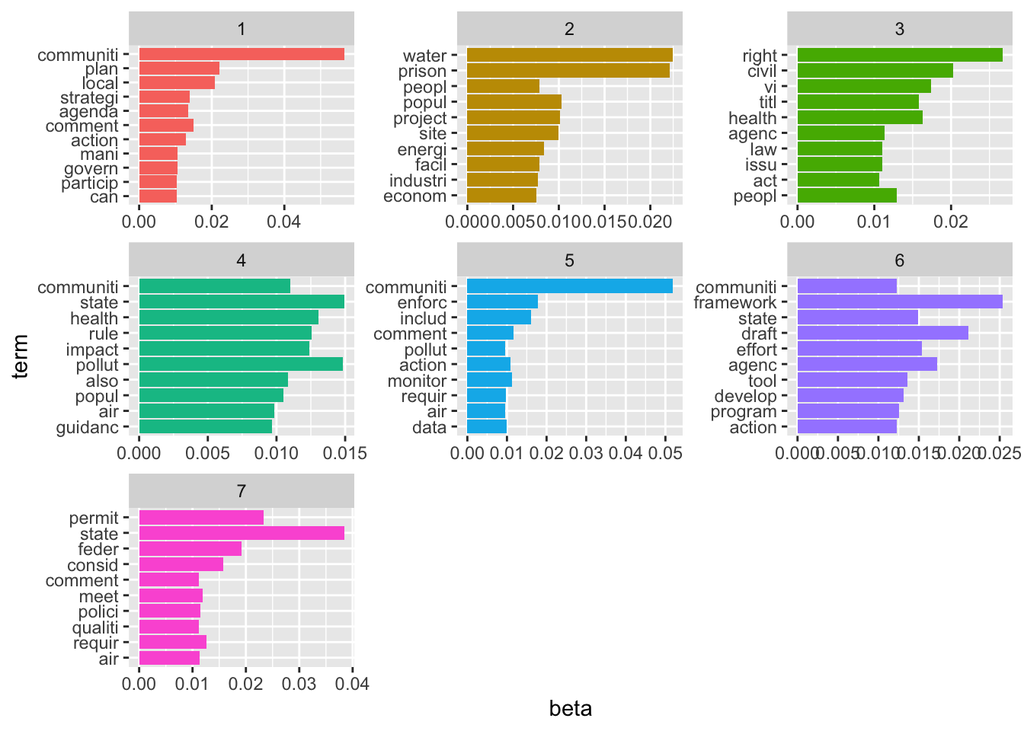

```r
top_terms %>%
  mutate(term = reorder(term, beta)) %>%
  ggplot(aes(term, beta, fill = factor(topic))) +
  geom_col(show.legend = FALSE) +
  facet_wrap(~ topic, scales = "free") +
  coord_flip()
```

Let’s assign names to the topics so we know what we are working with. We can name them by their top terms

```r
top5termsPerTopic <- terms(topicModel_k7, 5)
topicNames <- apply(top5termsPerTopic, 2, paste, collapse=" ")
```

We can explore the theta matrix, which contains the distribution of each topic over each document

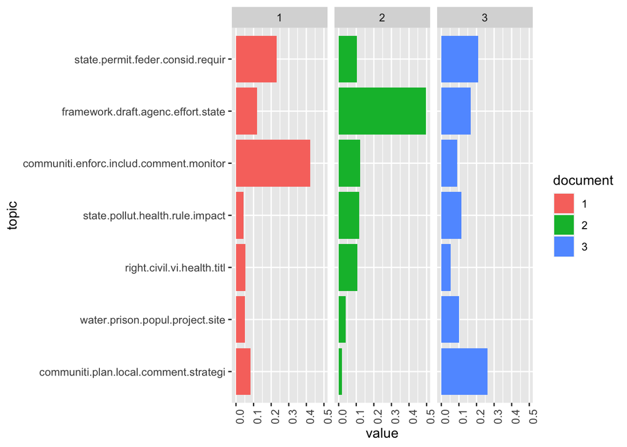

```r
exampleIds <- c(1, 2, 3)
N <- length(exampleIds)

#lapply(epa_corp[exampleIds], as.character) #uncomment to view example text
# get topic proportions form example documents
topicProportionExamples <- theta[exampleIds,]
colnames(topicProportionExamples) <- topicNames
vizDataFrame <- melt(cbind(data.frame(topicProportionExamples), document=factor(1:N)), variable.name = "topic", id.vars = "document")
ggplot(data = vizDataFrame, aes(topic, value, fill = document), ylab = "proportion") +
  geom_bar(stat="identity") +
  theme(axis.text.x = element_text(angle = 90, hjust = 1)) +
  coord_flip() +
  facet_wrap(~ document, ncol = N)
```

Here’s a neat JSON-based model visualizer

```r
library(LDAvis)
library("tsne")
svd_tsne <- function(x) tsne(svd(x)$u)
json <- createJSON(
  phi = tmResult$terms,
  theta = tmResult$topics,
  doc.length = rowSums(dfm),
  vocab = colnames(dfm),
  term.frequency = colSums(dfm),
  mds.method = svd_tsne,
  plot.opts = list(xlab="", ylab="")
)
serVis(json)
```

## Analysis continued

### 14 topics

```r
k <- 14

topicModel_k14 <- LDA(dfm, k, method="Gibbs", control=list(iter = 500, verbose = FALSE))

tmResult <- posterior(topicModel_k14)
attributes(tmResult)
```

```
## $names
## [1] "terms"  "topics"
```

```r
beta <- tmResult$terms   # get beta from results
dim(beta)                # K distributions over nTerms(DTM) terms# lengthOfVocab
```

```
## [1]   14 2781
```

```r
terms(topicModel_k14, 10)
```

```
##       Topic 1      Topic 2         Topic 3    Topic 4  Topic 5   Topic 6
##  [1,] "communiti"  "water"         "permit"   "health" "program" "help"
##  [2,] "pollut"     "communiti"     "state"    "park"   "feder"   "need"
##  [3,] "polici"     "juli"          "consid"   "peopl"  "state"   "work"
##  [4,] "comment"    "infrastructur" "comment"  "includ" "polici"  "peopl"
##  [5,] "power"      "may"           "use"      "law"    "requir"  "subject"
##  [6,] "reduc"      "local"         "grant"    "right"  "issu"    "make"
##  [7,] "protect"    "site"          "carolina" "citi"   "practic" "like"
##  [8,] "overburden" "drink"         "meet"     "color"  "order"   "sent"
##  [9,] "will"       "comment"       "air"      "green"  "may"     ">"
## [10,] "new"        "assist"        "opportun" "see"    "protect" "lung"
##       Topic 7      Topic 8     Topic 9     Topic 10   Topic 11    Topic 12
##  [1,] "prison"     "communiti" "framework" "industri" "communiti" "right"
##  [2,] "popul"      "enforc"    "draft"     "process"  "plan"      "agenc"
##  [3,] "facil"      "action"    "action"    "data"     "local"     "civil"
```

[output cut: 18 more lines]

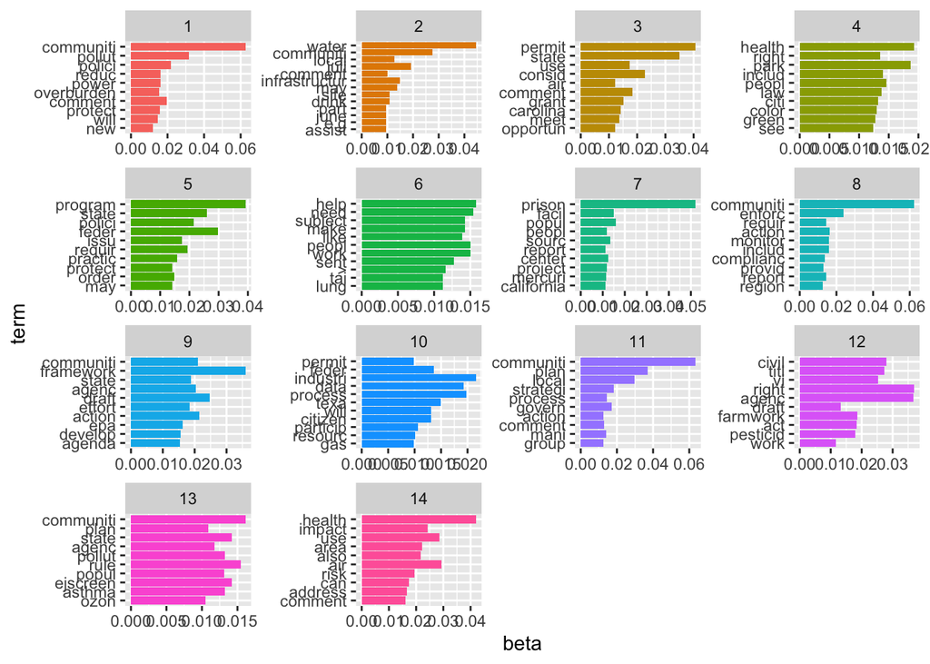

```r
comment_topics <- tidy(topicModel_k14, matrix = "beta")

top_terms <- comment_topics %>%
  group_by(topic) %>%
  top_n(10, beta) %>%
  ungroup() %>%
  arrange(topic, -beta)


top_terms %>%
  mutate(term = reorder(term, beta)) %>%
  ggplot(aes(term, beta, fill = factor(topic))) +
  geom_col(show.legend = FALSE) +
  facet_wrap(~ topic, scales = "free") +
  coord_flip()
```

### 10 topics

```r
k <- 10

topicModel_k10 <- LDA(dfm, k, method="Gibbs", control=list(iter = 500, verbose = FALSE))

tmResult <- posterior(topicModel_k10)
attributes(tmResult)
```

```
## $names
## [1] "terms"  "topics"
```

```r
beta <- tmResult$terms   # get beta from results
dim(beta)                # K distributions over nTerms(DTM) terms# lengthOfVocab
```

```
## [1]   10 2781
```

```r
terms(topicModel_k10, 10)
```

```
##       Topic 1     Topic 2     Topic 3      Topic 4   Topic 5    Topic 6
##  [1,] "rule"      "communiti" "framework"  "program" "prison"   "agenc"
##  [2,] "pollut"    "enforc"    "draft"      "state"   "facil"    "right"
##  [3,] "state"     "comment"   "communiti"  "requir"  "energi"   "titl"
##  [4,] "communiti" "includ"    "effort"     "will"    "industri" "issu"
##  [5,] "impact"    "monitor"   "develop"    "polici"  "popul"    "vi"
##  [6,] "air"       "permit"    "action"     "feder"   "water"    "civil"
##  [7,] "health"    "air"       "overburden" "regul"   "project"  "act"
##  [8,] "also"      "pollut"    "agenc"      "effect"  "center"   "plan"
##  [9,] "provid"    "action"    "state"      "follow"  "peopl"    "offic"
## [10,] "popul"     "complianc" "tool"       "process" "site"     "farmwork"
##       Topic 7         Topic 8     Topic 9   Topic 10
##  [1,] "communiti"     "work"      "health"  "state"
##  [2,] "local"         "plan"      "peopl"   "permit"
##  [3,] "comment"       "need"      "citi"    "consid"
##  [4,] "water"         "strategi"  "park"    "use"
##  [5,] "govern"        "action"    "right"   "feder"
##  [6,] "juli"          "make"      "climat"  "air"
##  [7,] "particip"      "communiti" "see"     "framework"
##  [8,] "resourc"       "subject"   "address" "meet"
##  [9,] "infrastructur" "comment"   "color"   "opportun"
## [10,] "agenda"        "year"      "polici"  "carolina"
```

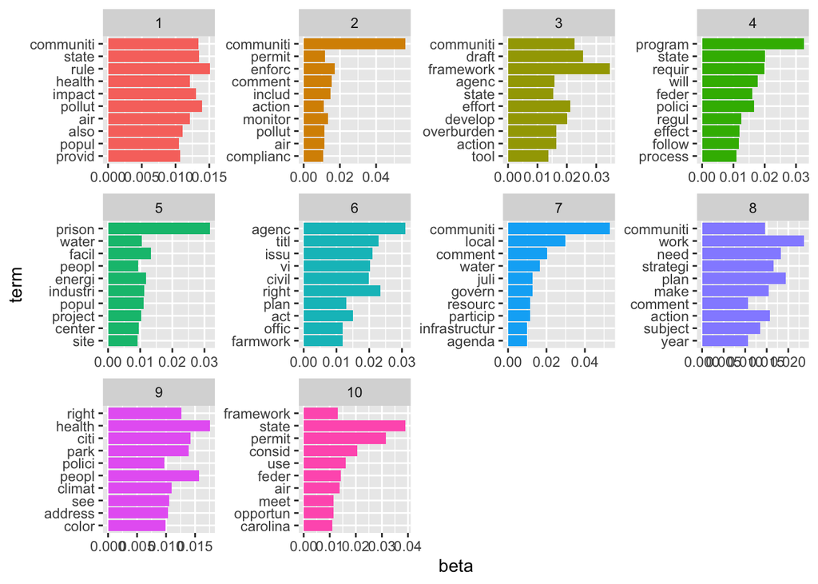

```r
comment_topics <- tidy(topicModel_k10, matrix = "beta")

top_terms <- comment_topics %>%
  group_by(topic) %>%
  top_n(10, beta) %>%
  ungroup() %>%
  arrange(topic, -beta)


top_terms %>%
  mutate(term = reorder(term, beta)) %>%
  ggplot(aes(term, beta, fill = factor(topic))) +
  geom_col(show.legend = FALSE) +
  facet_wrap(~ topic, scales = "free") +
  coord_flip()
```

### 8 Topics

```r
k <- 8

topicModel_k8 <- LDA(dfm, k, method="Gibbs", control=list(iter = 500, verbose = FALSE))

tmResult <- posterior(topicModel_k8)
attributes(tmResult)
```

```
## $names
## [1] "terms"  "topics"
```

```r
beta <- tmResult$terms   # get beta from results
dim(beta)                # K distributions over nTerms(DTM) terms# lengthOfVocab
```

```
## [1]    8 2781
```

```r
terms(topicModel_k8, 8)
```

```
##      Topic 1      Topic 2  Topic 3     Topic 4     Topic 5     Topic 6
## [1,] "communiti"  "right"  "communiti" "framework" "communiti" "prison"
## [2,] "new"        "civil"  "plan"      "draft"     "enforc"    "site"
## [3,] "comment"    "health" "local"     "agenc"     "includ"    "can"
## [4,] "pollut"     "vi"     "agenda"    "effort"    "requir"    "project"
## [5,] "polici"     "titl"   "strategi"  "action"    "monitor"   "water"
## [6,] "overburden" "agenc"  "use"       "program"   "health"    "peopl"
## [7,] "will"       "peopl"  "work"      "epa"       "plan"      "energi"
## [8,] "impact"     "includ" "govern"    "develop"   "action"    "juli"
##      Topic 7  Topic 8
## [1,] "state"  "rule"
## [2,] "permit" "pollut"
## [3,] "feder"  "state"
## [4,] "consid" "communiti"
## [5,] "polici" "popul"
## [6,] "use"    "impact"
## [7,] "air"    "health"
## [8,] "train"  "also"
```

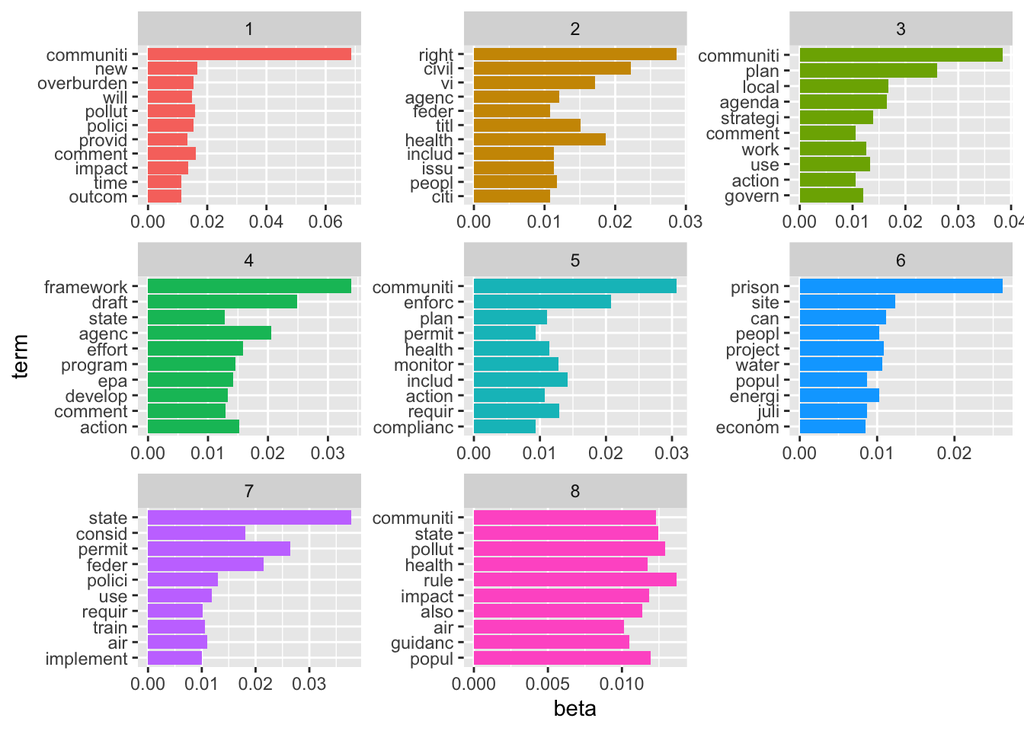

```r
comment_topics <- tidy(topicModel_k8, matrix = "beta")

top_terms <- comment_topics %>%
  group_by(topic) %>%
  top_n(10, beta) %>%
  ungroup() %>%
  arrange(topic, -beta)


top_terms %>%
  mutate(term = reorder(term, beta)) %>%
  ggplot(aes(term, beta, fill = factor(topic))) +
  geom_col(show.legend = FALSE) +
  facet_wrap(~ topic, scales = "free") +
  coord_flip()
```

## Best value for k

Based on the Deveaud2014 metric in the `FindTopicsNumber()` analysis, I chose to try 10, 14, and 8 as possible numbers of topics. I assessed these models by looking at the frequency of top terms in each topic and with the `LDAvis` app. After running these additional models, I think that 8 topics has been the most successful so far. In my opinion it seems like when more than 8 topics are formed, they start to become more redundant and the lines between them start to blur. In part, I based this on looking at the top words in each supposed topic and feeling out how cohesive and unique each was. Using `LDAvis`, it appears using 8 topics creates a fairly equidistant spacing between the topics—as the topics increase beyond this amount, certain topics start to become closer to one another. This choice would align fairly well with Deveaud2014 metric, as 8 was one of topic numbers with a higher value, albeit not among the very highest values.